# SpotifyR report

Author

Ayala Beck

# Bob Marley’s story

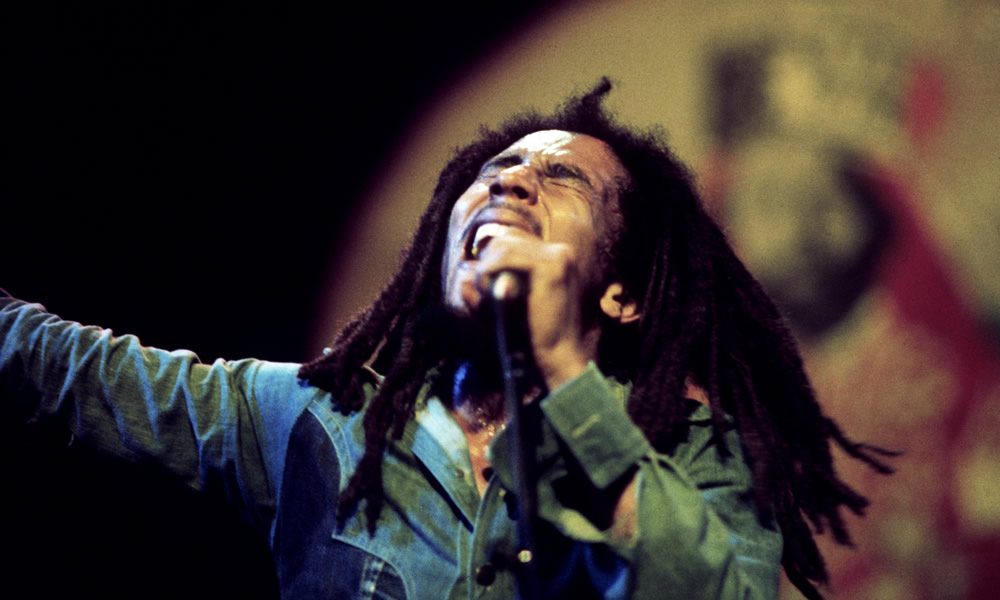

### His life

- Reggae pioneer
- released his first album at 18 with a group of teenagers called The Wailers
- born in 1945 in Jamaica and died in 1981

```r
#first I have to get the data and the packages
library(dplyr)
library(ggplot2)
bmd<-read.csv("Bob Marley & The Wailers.csv")
```

### Overview over his music

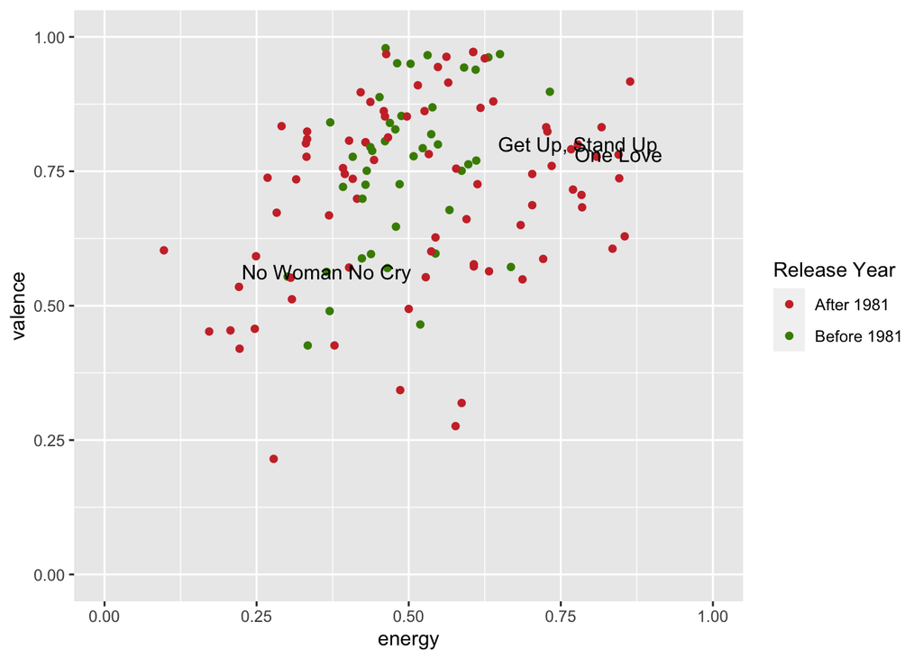

```r
# I have tried to find the charateristics of his music here by plotting first the energy and valance to find the mood, and then speechiness and valence to find the pace of speaking in relation to the mood.
famoussongs<-bmd |> filter(track_name %in% c("One Love", "Get Up, Stand Up", "No Woman No Cry"))

ggplot(bmd, aes(x=energy, y=valence))+
  geom_point(aes(color=case_when(
    album_release_year<1982~"Before 1981",
    album_release_year>1982 ~ "After 1981")))+
  xlim(0,1)+ylim(0,1)+
  geom_text(data=famoussongs, aes(label=track_name)) +
  scale_color_manual(values = c("Before 1981" = "chartreuse4", "After 1981" = "brown3")) +
  labs(color = "Release Year")
```

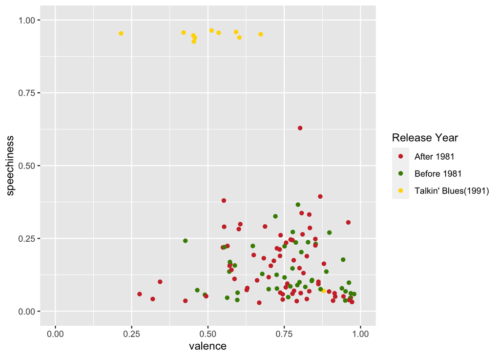

```r
ggplot(bmd, aes(x=valence, y=speechiness))+
  geom_point(aes(color=case_when(
    album_release_year==1991~"Talkin' Blues(1991)",
    album_release_year<1982~"Before 1981",
    album_release_year>1982~"After 1981")))+
  xlim(0,1)+ylim(0,1)+
  scale_color_manual(values = c("Before 1981"="chartreuse4", "After 1981"="brown3", "Talkin' Blues(1991)"="gold1"))+
  labs(color="Release Year")
```

The first graph is really interesting as it shows that the vast majority of Bob Marley’s songs are positive! The energy level tends to be in the middle of the scale, with most data points between 0.25 and 0.75. It also seems that songs released while he was still alive are even more centralized regarding their energy: most points are between 37.5 and 62.5.

The second graph shows the the speechiness of his songs is rather low, except for one album called Talkin’ Blues, that includes interview segments with Bob Marley.

### His lifetime

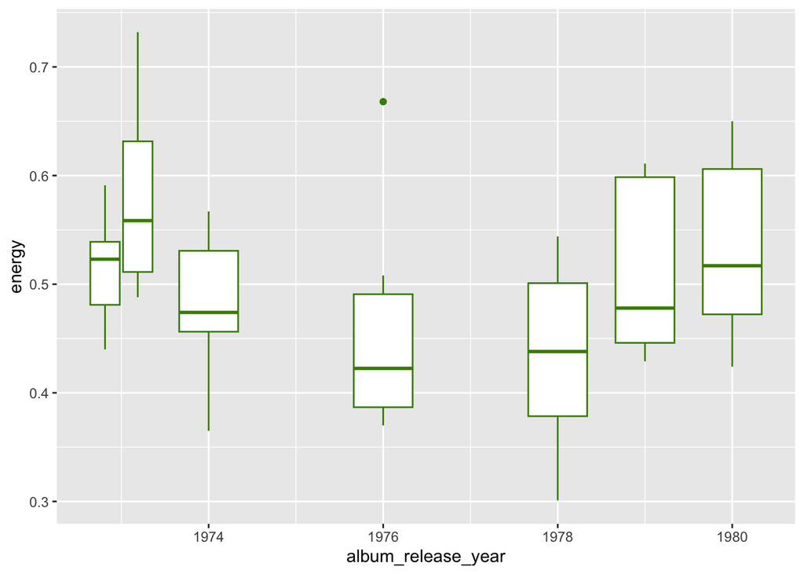

```r
#here I tried to find whether his energy level changed thoughout his lifetime
ggplot(bmd, aes(group=album_name, x=album_release_year, y=energy))+
  geom_boxplot(data=bmd %>% filter(album_release_year<1982), color='chartreuse4')
```

This graph shows that while he had higher levels of energy in his songs in the beginning and end of his career, this could maybe be the case because he was shot and injured in 1976, or because he has moved to England after being shot until 1978.

### After His Death

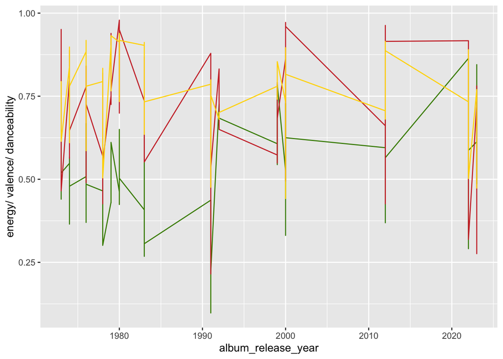

```r
#here I created line graphs to show Bob Marley's music's development over time.
ggplot(bmd)+
  geom_line(aes(x=album_release_year, y=energy), color='chartreuse4')+
  geom_line(aes(x=album_release_year, y=valence), color='brown3')+
  geom_line(aes(x=album_release_year, y=danceability), color='gold1')+
  labs(y="energy/ valence/ danceability")
```

In this graph I was trying to see whether the energy, valence, and danceability show a different trend after Bob Marley’s death, or in other words, what kind of songs were released when he was no longer alive. While the graph doesn’t show a clear trend, it seems that danceability and valence have stayed rather constant, and that the energy of the songs increased a bit after his death (1981).

### My favorite song

[video not shown]

[figure not shown]